### Spatial vector data: Points, lines, polygons

In the last class we examined rasters, or gridded spatial data. The other way we typically deal with spatial data is through vector data, which consists of points, lines and polygons. The most common file format for passing along spatial vector data is the shapefile.

- points: a single x,y coordinate pair (tree, city)
- lines: 2 or more points that are connected (stream, road)
- polygons: 3 or more points that form a closed shape (lake, country)

Geospatial data in vector format are often stored in a shapefile format. Shapefiles were developed by Esri (the ArcGIS company). Because the structure of points, lines, and polygons are different, each individual shapefile can only contain one vector type (all points, all lines or all polygons). You will not find a mixture of point, line and polygon objects in a single shapefile. Shapefiles are actually a collection of files with a common filename prefix and stored in the same directory. In R, the whole set of shapefiles with a common filename prefix can be read in simultaneously with a single load command.

Objects stored in a shapefile often have a set of associated attributes that describe the data. For example, a line shapefile that contains the locations of streams, might contain the associated stream name, and other information about each stream line object.

### sf package

Let’s start by loading the libraries we are going to use. The new `sf` package gives us tools to work with spatial data in `data.frame` and `tibble` formats to play nicely with the `tidyverse` workflows we have been practicing. An `sf` (simple features) object is a data.frame (or tibble) with rows of features, columns of attributes and a special geometry column that contains the spatial aspects of the features. The geometry columns contains a list of class `sfc` (simple features column), which is made up of individual objects of class `sfg` (simple features geometries) and a CRS (Coordinate Reference System). The `sfg` objects each represent the geometry of a single feature and contains information about the feature’s coordinates, dimension and type of geometry. (Most spatial data, including everything we’ll work with in class, is 2-dimensional with X and Y coordinates). The geometry type indicates the shape of a feature. Here are the most common geometry types:

*Geometry types*

- `POINT`: a single point
- `MULTIPOINT`: multiple points
- `LINESTRING`: sequence of two or more points connected by straight lines
- `MULTILINESTRING`: multiple lines
- `POLYGON`: a closed ring with zero or more interior holes
- `MULTIPOLYGON`: multiple polygons
- `GEOMETRYCOLLECTION`: any combination of the above types

All functions and methods in the `sf` package that operate on spatial data are preceded by the prefix `st_` which refers to *spatial type*.

### North Atlantic right whales

We will practice using spatial vector data by recreating a figure I made for a policy-oriented paper on the critically endangered North Atlantic right whale. Right whales are heavily impacted by human activities, and are frequently killed by ship strikes or entanglement in fishing gear. For decades, US and Canadian martitime agencies (especially NOAA and the DFO) implement regulations to reduce ship speeds, modify fishing gear and limit fishing activity in right whale hot spots. In 2017, right whales experienced an Unexpected Mortality Event when 17 carcasses were discovered over the course of a single year. This was the result of an abrupt shift in right whale distribution in response to climate-driven changes to prey availability. By mapping the boundaries of right whale critical habitats in the US and Canada alongside the location of right whale carcasses, we can assess the efficacy of fishery and shipping regulations, and the failure of these regulations in 2017.

```r
library(sf) # simple features (spatial vector data) st_read, st_transform
# library(broom) # part of tidyverse
library(tidyverse)
library(mapdata)  # map_data
library(marmap) # getNOAA.bathy()
```

### Reading and organizing disparate spatial datasets

Now we are going to load in three right whale datasets. (This data is all publicly available, but it required me to combine multiple, messy, sources as well as data requests from the North Atlantic Right Whale Consortium.) We’ll load:

1. shapefiles that contain polygons corresponding to the boundaries of right whale critical habitats in the US in 2017
2. a .csv file that contains the lat/lon boundaries of right whale critical habitats in Canada in 2017
3. a .csv file that contains the location and other info about right whale carcasses found in 2017

To read in the US critical habitat shapefiles, we use `sf:st_read()`. We take a look at the data and see that the CRS is EPSG code 4269, which is the NAD83 projection. [The 4-digit EPSG (European Petroleum Survey Group Geodetic Parameter Dataset) is a public registry of spatial reference systems. The NAD83 projection is the North American Datum 1983 CRS, which is most commonly used by US federal agencies.] In this exercise, we are going to use CRS WGS84 [World Geodetic System 1984; EPSG 4326.] so we’ll use `st_transform()` to transform our data from one CRS to another.

```r
# Carcass location data
carcass = read.csv('data/RW_carcasses_2017.csv')

#Read in US critical habitat shapefiles
# https://www.greateratlantic.fisheries.noaa.gov/educational_resources/gis/data/index.html
USA_crit_hab = st_read('data/North_Atlantic_Right_Whale_Critical_Habitat/','North_Atlantic_Right_Whale_Critical_Habitat') # reads in set of shapefiles
## Reading layer `North_Atlantic_Right_Whale_Critical_Habitat' from data source `/Users/eringubrod/Dropbox/Teaching/MSCI599_EnvDataSci_R/MSCI599_Course_Files/unit_5_spatial/data/North_Atlantic_Right_Whale_Critical_Habitat' using driver `ESRI Shapefile'
## Simple feature collection with 2 features and 23 fields
## geometry type:  POLYGON
## dimension:      XY
## bbox:           xmin: -81.46045 ymin: 28 xmax: -66.88542 ymax: 44.82886
## CRS:            4269
USA_crit_hab
## Simple feature collection with 2 features and 23 fields
## geometry type:  POLYGON
## dimension:      XY
## bbox:           xmin: -81.46045 ymin: 28 xmax: -66.88542 ymax: 44.82886
## CRS:            4269
##   GARFO_ID                                               AREANAME
## 1  G000371 Critical Habitat for North Atlantic Right Whale Unit 1
## 2  G000372 Critical Habitat for North Atlantic Right Whale Unit 2
##                                    COMMNAME
## 1 Right Whale Critical Habitat Feeding Area
## 2 Right Whale Critical Habitat Calving Area
##                                          AREAGROUP
## 1 Critical Habitat for North Atlantic right whales
## 2 Critical Habitat for North Atlantic right whales
##                                               DESCRIBE CFRTITLE CFRPT
## 1 Protects North Atlantic right whale foraging habitat       50   226
## 2  Protects North Atlantic right whale calving habitat       50   226
##                      CFRPTTXT CFRSUB CFRSUBTXT  CFRSXN
## 1 Designated Critical Habitat   NULL      NULL 226.203
## 2 Designated Critical Habitat   NULL      NULL 226.203
##                                                                CFRSXNTXT
## 1 Critical habitat for North Atlantic right whales (Eubalaena glacialis)
## 2 Critical habitat for North Atlantic right whales (Eubalaena glacialis)
##         CFRPARA CFRPARATXT     FRCITE    FRDATE EFFECTDATE SOURCE RECURST
## 1 226.203(b)(1)     Unit 1 81 FR 4838 1/27/2016  2/26/2016    CFR     n/a
## 2 226.203(b)(2)     Unit 2 81 FR 4838 1/27/2016  2/26/2016    CFR     n/a
##   RECUREND GISAUTHOR   CREATED
## 1      n/a  DSzumylo 1/26/2016
## 2      n/a    AFrick 1/26/2016
##                                                                                                     AREANOTES
## 1   Unit 1, in the Gulf of Maine, falls under the jurisdiction of the NOAA Fisheries Greater Atlantic Region.
## 2 Unit 2, off the southeastern US coast, falls under the jurisdiction of the NOAA Fisheries Southeast Region.
##                         geometry
## 1 POLYGON ((-70.48991 41.7727...
## 2 POLYGON ((-78.16205 33.9149...
USA_crit_hab_sf = st_transform(USA_crit_hab, crs=4326) #crs="+proj=longlat +datum=WGS84")
```

To get the Canadian critical habitat boundaries, we read in the series of polygon points provided in a simple .csv file. These are latitude/longitude coordinates with the CRS WGS84. We can conver the data frame into a simple features data frame using `st_as_sf()`. To do this, we must tell the function `st_as_sf()` which columns should be used as the X and Y coordinates, and what the CRS is. This gives us a simple features data frame with point geometries.

Next we need to turn our points into polygons (i.e. the boundaries of our critical habitats). To this we can use `dplyr` functions that have been created for simple features. We’ll group our POINTS by habitat and country (grouping by country doesn’t accomplish anything in this case since all of the points are in Canada, but including it in the grouping allows us to retain this column when we use `summarize()`). Then we’ll use summarize to collapse the POINTS into 2 MULTIPOINT geometry types (one for Grand Manan Basin, one for Roseway Basin). As you recall from using `summarize()` previously, this function drops all columns except the column(s) that the data have been grouped by and the column(s) that you create in the `summarize()` function. However, when using `dplyr` on sf objects, the geometries are “sticky”, meaning that the geometry column of sf objects is retained unless the user deliberately removes it. So we have used `summarize()` to convert the POINTs in each habitat to a single MULTIPOINT geometry. Whew. Finally, we used the parameter `do_union=FALSE`. This triggers the `summarize()` function to use `st_combine()` instead of `st_union()` to collapse our POINTs into MULTIPOINTs. This only matters because the `st_union()` function does not preserve POINT order, and if our POINTs get out of order, then the POLYGON that we create will be wonky (check out `?summarise.sf`). Finally, we use `st_cast()` to turn our MULTIPOINT geometries into POLYGONs.

```r
#Load in Canadian RW critical habitat coordinates http://www.dfo-mpo.gc.ca/species-especes/profiles-profils/rightwhaleNA-baleinenoireAN-eng.html
CAN_crit_hab = read.csv('data/NARW_canadian_critical_habitat_2017.csv')
head(CAN_crit_hab)
```

```
##        lat       lon           habitat country
## 1 44.81667 -66.45000 Grand_Manan_Basin  Canada
## 2 44.78333 -66.28333 Grand_Manan_Basin  Canada
## 3 44.66667 -66.28333 Grand_Manan_Basin  Canada
## 4 44.55000 -66.36667 Grand_Manan_Basin  Canada
## 5 44.48333 -66.50000 Grand_Manan_Basin  Canada
## 6 44.48333 -66.61667 Grand_Manan_Basin  Canada
```

```r
# Turn data frame into sf points, then sf polygon
CAN_crit_hab_sf = CAN_crit_hab %>%
  st_as_sf(coords=c("lon","lat"), crs=4326) %>% # convert to sf
  dplyr::group_by(habitat, country) %>%
  dplyr::summarise(do_union=FALSE) %>% # collapses data into multipoint; do_union=FALSE prevents reordering points; check out ?summarise.sf
  st_cast("POLYGON")
## `summarise()` regrouping output by 'habitat' (override with `.groups` argument)
print(CAN_crit_hab_sf) # 2 simple features, with habitat and country attributes
## Simple feature collection with 2 features and 2 fields
## geometry type:  POLYGON
## dimension:      XY
## bbox:           xmin: -66.61667 ymin: 42.65 xmax: -64.91667 ymax: 44.81667
## CRS:            EPSG:4326
## # A tibble: 2 x 3
## # Groups:   habitat [2]
##   habitat       country                                                 geometry
##   <fct>         <fct>                                              <POLYGON [°]>
## 1 Grand_Manan_… Canada  ((-66.45 44.81667, -66.28333 44.78333, -66.28333 44.666…
## 2 Roseway_Basin Canada  ((-64.91667 43.26667, -64.98333 42.78333, -65.51667 42.…
```

Now let’s get our USA habitat and our Canada habitat data ready to be joined. We’ll give the USA data the same attributes as the Canadian data: habitat and country. Then the USA and Canadian habitat data have the same attributes, the same geometric types (POLYGON) and the same CRS. Now we can just use `rbind()` to combine them into a single `sf` object!

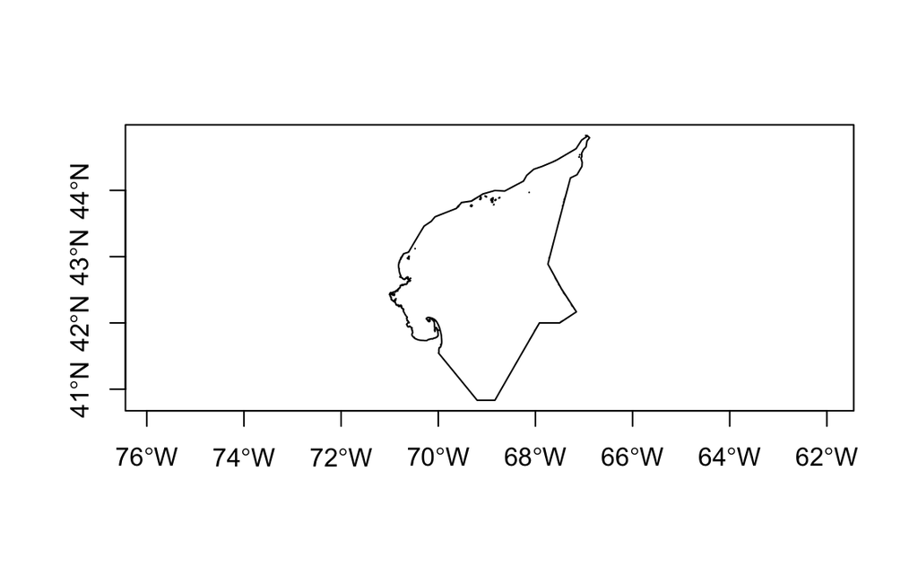

```r
# Simply USA_crit_hab data frame to match CAN_crit_hab
plot(USA_crit_hab_sf$geometry[1], axes=TRUE) # GOM habitat
```

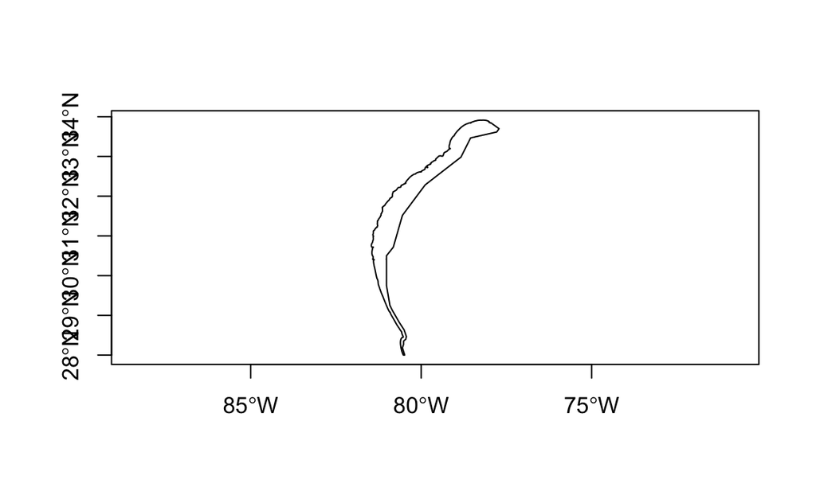

```r
plot(USA_crit_hab_sf$geometry[2], axes=TRUE) # FL / GA habitat
```

```r
USA_crit_hab_sf$habitat=c("NMFS_GOM", "SEUS")
USA_crit_hab_sf$country="USA"
USA_crit_hab_sf = USA_crit_hab_sf %>% select(country, habitat, geometry) # drops all other variables from shapefile

# Join the USA and Canada critical habitat sf objects
crit_hab = rbind(USA_crit_hab_sf, CAN_crit_hab_sf)
```

### Making maps

So that was a lot of hard work merging our USA and Canada datasets because their original formats were very different. Different file types (.csv vs. shapefile), different geometries (coordinates vs. polygons), different attributes and different CRSs. Now that we have combined these disparate datasets, we can use `ggplot2` tools to turn this spatial vector data into maps!

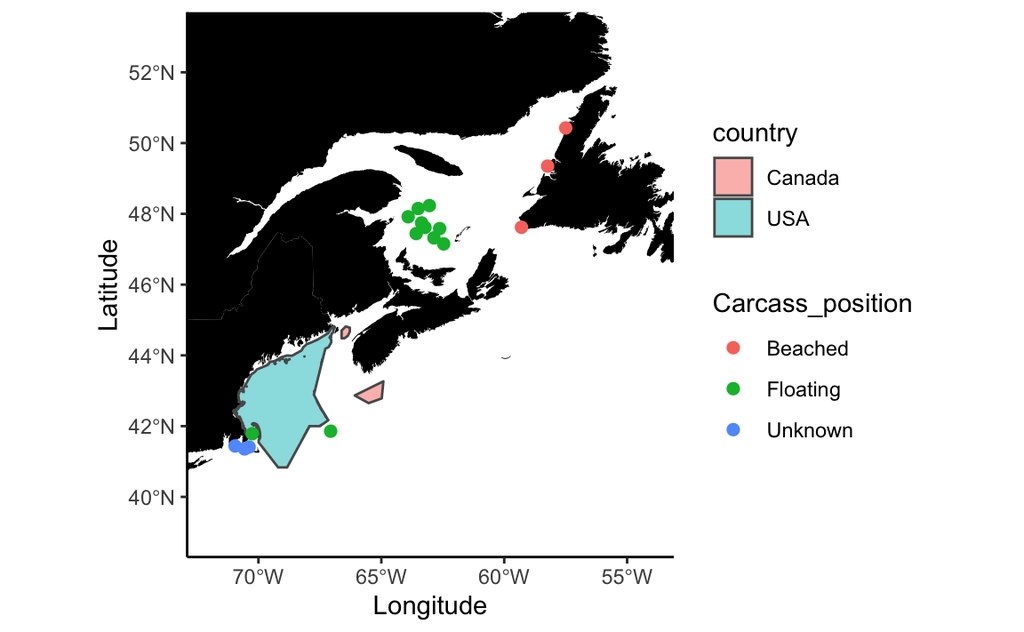

```r
# set GOM + GSL map limits
lon_bounds = c(-72, -54)
lat_bounds = c(39, 53)

# Coastline data
world_map = map_data("worldHires", ylim = lat_bounds, xlim = lon_bounds)

# plot critical habitats and carcass locations
ggplot()+
  geom_polygon(data = world_map, aes(x = long, y = lat, group = group), fill = "black") + # add coastline
  geom_sf(data=crit_hab, alpha = 0.5, aes(fill=country)) +
  geom_point(data = carcass, aes(x = Longitude, y = Latitude, color = Carcass_position), size=2) +
  coord_sf(1.3, xlim = lon_bounds, ylim = lat_bounds) + # Crop map edges
  ylab("Latitude") + xlab("Longitude") + theme_classic()
```

We can use what we learned in the previous tutorial to add bathymetry data beneath our critical habitat polygons and our carcass data.

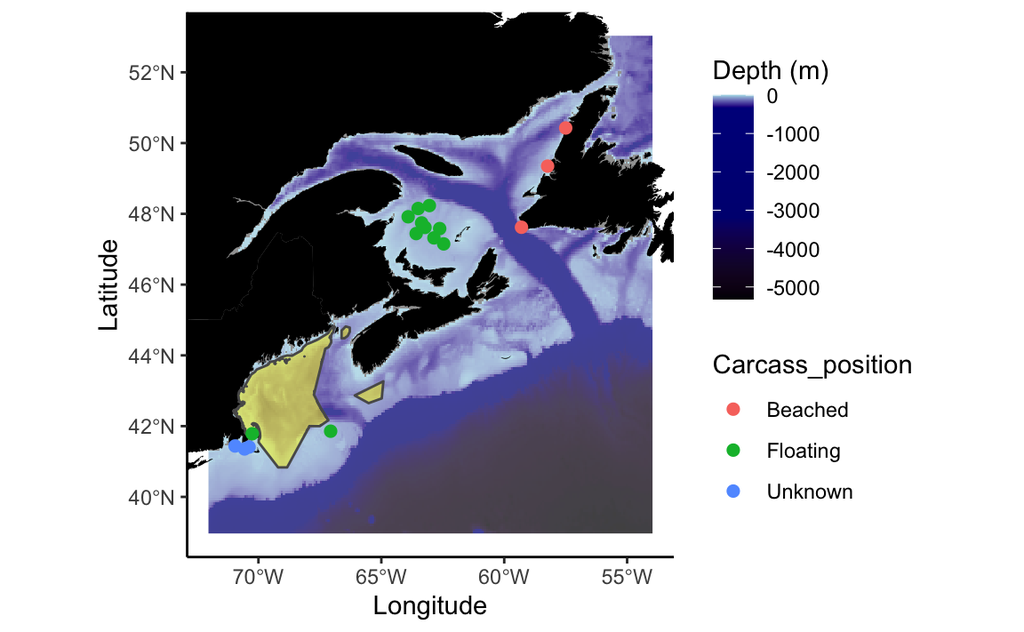

```r
#library(ggnewscale)  # new_scale_fill() add to ggplot to create 2nd fill scale
bath_m_raw = marmap::getNOAA.bathy(lon1 = lon_bounds[1], lon2 = lon_bounds[2],
                                   lat1 = lat_bounds[1], lat2 = lat_bounds[2], resolution = 4) # resolution default: 4 minutes
## Querying NOAA database ...
## This may take seconds to minutes, depending on grid size
## Building bathy matrix ...
# convert bathymetry to data frame
bath_m_fortify = marmap::fortify.bathy(bath_m_raw)
bath_m = bath_m_fortify %>%
  mutate(depth_m = ifelse(z>0, NA, z)) %>%
  dplyr::select(-z)
# head(bath_m)
# summary(bath_m)

# plot critical habitats and carcass locations over bathymetry
rw_map = ggplot()+
  geom_raster(data = bath_m , aes(x = x, y = y, fill = depth_m), alpha=0.75) +
  scale_fill_gradientn(colors=c("black", "navy", "blue4","lightblue"),
                       values = scales::rescale(c(-5000, -3000, -300, 0)),
                       name="Depth (m)") +
  geom_polygon(data = world_map, aes(x = long, y = lat, group = group), fill = "black", color = NA) +
  geom_sf(data=crit_hab, alpha = 0.5, fill='yellow') +
  geom_point(data = carcass, aes(x = Longitude, y = Latitude, color = Carcass_position), size=2) +
  coord_sf(1.3, xlim = lon_bounds, ylim = lat_bounds) + # Crop map edges
  ylab("Latitude") + xlab("Longitude") + theme_classic()

rw_map
```

```r
ggsave(rw_map, filename='figures/RW_habitats.pdf', device="pdf", height=5, width=7)

## How many carcass locations occur in critical habitat zones?
```

### Exercise 2.1

Take a look at the map we created. How many right whale carcasses were discovered inside of the critical habitats? What might you infer about the efficacy of the critical habitats at protecting right whales? What might you infer about the locations of those critical habitat boundaries?

### Acknowledgements

Here is a great blog about simple features in R: https://www.jessesadler.com/post/simple-feature-objects/